# TMDB MOVIE DATASET

## TMBD MOVIE DATA

An analysis of 10,000 movies collected from the movie database. I'll begin by exploring the dataset; from the exploration, I'll then determine questions that I wish to answer. First, I'll download the data to my local system. Next step is to explore it. I'll begin by looking through the available fields/columns to get an understanding of the data and a sense of questions I could answer.

Everyone watches movies; for most people, it serves as a form of entertainment and relaxation. By exploring this dataset, I'll like to get an insight into the types of movies people like and the cotributing factors.

```python
# import necessary packages: pandas, numpy, matplotlib, seaborn
# Then explore data to get an understanding of the data
import pandas as pd
import numpy as np
from matplotlib import pyplot as plt
import seaborn as sns
%matplotlib inline

df_movies = pd.read_csv('/Users/ifunanya/Downloads/tmdb-movies.csv')
df_movies.head()
```

|  | id | imdb_id | popularity | budget | revenue | original_title | cast | homepage | director | tagline | ... | overview | runtime | genres | production_companies | release_date | vote_count | vote_average | release_year | budget_adj | revenue_adj |
| --- | --- | --- | --- | --- | --- | --- | --- | --- | --- | --- | --- | --- | --- | --- | --- | --- | --- | --- | --- | --- | --- |
| 0 | 135397 | tt0369610 | 32.985763 | 150000000 | 1513528810 | Jurassic World | Chris Pratt\|Bryce Dallas Howard\|Irrfan Khan\|Vi... | http://www.jurassicworld.com/ | Colin Trevorrow | The park is open. | ... | Twenty-two years after the events of Jurassic ... | 124 | Action\|Adventure\|Science Fiction\|Thriller | Universal Studios\|Amblin Entertainment\|Legenda... | 6/9/15 | 5562 | 6.5 | 2015 | 1.379999e+08 | 1.392446e+09 |
| 1 | 76341 | tt1392190 | 28.419936 | 150000000 | 378436354 | Mad Max: Fury Road | Tom Hardy\|Charlize Theron\|Hugh Keays-Byrne\|Nic... | http://www.madmaxmovie.com/ | George Miller | What a Lovely Day. | ... | An apocalyptic story set in the furthest reach... | 120 | Action\|Adventure\|Science Fiction\|Thriller | Village Roadshow Pictures\|Kennedy Miller Produ... | 5/13/15 | 6185 | 7.1 | 2015 | 1.379999e+08 | 3.481613e+08 |
| 2 | 262500 | tt2908446 | 13.112507 | 110000000 | 295238201 | Insurgent | Shailene Woodley\|Theo James\|Kate Winslet\|Ansel... | http://www.thedivergentseries.movie/#insurgent | Robert Schwentke | One Choice Can Destroy You | ... | Beatrice Prior must confront her inner demons ... | 119 | Adventure\|Science Fiction\|Thriller | Summit Entertainment\|Mandeville Films\|Red Wago... | 3/18/15 | 2480 | 6.3 | 2015 | 1.012000e+08 | 2.716190e+08 |
| 3 | 140607 | tt2488496 | 11.173104 | 200000000 | 2068178225 | Star Wars: The Force Awakens | Harrison Ford\|Mark Hamill\|Carrie Fisher\|Adam D... | http://www.starwars.com/films/star-wars-episod... | J.J. Abrams | Every generation has a story. | ... | Thirty years after defeating the Galactic Empi... | 136 | Action\|Adventure\|Science Fiction\|Fantasy | Lucasfilm\|Truenorth Productions\|Bad Robot | 12/15/15 | 5292 | 7.5 | 2015 | 1.839999e+08 | 1.902723e+09 |
| 4 | 168259 | tt2820852 | 9.335014 | 190000000 | 1506249360 | Furious 7 | Vin Diesel\|Paul Walker\|Jason Statham\|Michelle ... | http://www.furious7.com/ | James Wan | Vengeance Hits Home | ... | Deckard Shaw seeks revenge against Dominic Tor... | 137 | Action\|Crime\|Thriller | Universal Pictures\|Original Film\|Media Rights ... | 4/1/15 | 2947 | 7.3 | 2015 | 1.747999e+08 | 1.385749e+09 |

5 rows × 21 columns

The dataset has 21 columns which are explained briefly below:

| COLUMN NAME | DESCRIPTION |
| --- | --- |
| Id | The ID of the movie |
| Imdb_id | The IMDB ID of the movie |
| Popularity | Popularity score of the movie assigned by TMDB |
| Budget | Movie budget in dollars |
| Revenue | Revenue budget in dollars |
| Original_title | Original title of the movie |
| Cast | Actors and actresses associated with the movie |
| Homepage | Official homepage of the movie |
| Director | Movie director |
| Tagline | Tagline other than the title |
| Overview | Brief breakdown of the movie |
| Runtime | Length/duration of the movie |
| Genres | List of genres associated with the movie |
| Production_companies | Production companies associated with the making of the movie |
| Release_date | Release date of the movie |
| Vote_count | Number of individuals who voted |
| Vote_average | Average rating of the movie |
| Release_year | Year of release |
| Budget_adj | Movie budget adjusted |
| Revenue_adj | Revenue budget adjusted |

```python
df_movies.shape
```

```
(10866, 21)
```

The dataset contains 10,866 rows and 21 columns. Next, we'll get more information on the dataset.

```python
df_movies.info()
```

```
<class 'pandas.core.frame.DataFrame'>
RangeIndex: 10866 entries, 0 to 10865
Data columns (total 21 columns):
 #   Column                Non-Null Count  Dtype
---  ------                --------------  -----
 0   id                    10866 non-null  int64
 1   imdb_id               10856 non-null  object
 2   popularity            10866 non-null  float64
 3   budget                10866 non-null  int64
 4   revenue               10866 non-null  int64
 5   original_title        10866 non-null  object
 6   cast                  10790 non-null  object
 7   homepage              2936 non-null   object
 8   director              10822 non-null  object
 9   tagline               8042 non-null   object
 10  keywords              9373 non-null   object
 11  overview              10862 non-null  object
 12  runtime               10866 non-null  int64
 13  genres                10843 non-null  object
 14  production_companies  9836 non-null   object
 15  release_date          10866 non-null  object
 16  vote_count            10866 non-null  int64
 17  vote_average          10866 non-null  float64
 18  release_year          10866 non-null  int64
 19  budget_adj            10866 non-null  float64
 20  revenue_adj           10866 non-null  float64
dtypes: float64(4), int64(6), object(11)
memory usage: 1.7+ MB
```

All datatypes are fitting for their respective columns. However, we observe null values in homepage, cast, director, tagline, keyword, overview, genres, production companies.

```python
df_movies.describe()
```

|  | id | popularity | budget | revenue | runtime | vote_count | vote_average | release_year | budget_adj | revenue_adj |
| --- | --- | --- | --- | --- | --- | --- | --- | --- | --- | --- |
| count | 10866.000000 | 10866.000000 | 1.086600e+04 | 1.086600e+04 | 10866.000000 | 10866.000000 | 10866.000000 | 10866.000000 | 1.086600e+04 | 1.086600e+04 |
| mean | 66064.177434 | 0.646441 | 1.462570e+07 | 3.982332e+07 | 102.070863 | 217.389748 | 5.974922 | 2001.322658 | 1.755104e+07 | 5.136436e+07 |
| std | 92130.136561 | 1.000185 | 3.091321e+07 | 1.170035e+08 | 31.381405 | 575.619058 | 0.935142 | 12.812941 | 3.430616e+07 | 1.446325e+08 |
| min | 5.000000 | 0.000065 | 0.000000e+00 | 0.000000e+00 | 0.000000 | 10.000000 | 1.500000 | 1960.000000 | 0.000000e+00 | 0.000000e+00 |
| 25% | 10596.250000 | 0.207583 | 0.000000e+00 | 0.000000e+00 | 90.000000 | 17.000000 | 5.400000 | 1995.000000 | 0.000000e+00 | 0.000000e+00 |
| 50% | 20669.000000 | 0.383856 | 0.000000e+00 | 0.000000e+00 | 99.000000 | 38.000000 | 6.000000 | 2006.000000 | 0.000000e+00 | 0.000000e+00 |
| 75% | 75610.000000 | 0.713817 | 1.500000e+07 | 2.400000e+07 | 111.000000 | 145.750000 | 6.600000 | 2011.000000 | 2.085325e+07 | 3.369710e+07 |
| max | 417859.000000 | 32.985763 | 4.250000e+08 | 2.781506e+09 | 900.000000 | 9767.000000 | 9.200000 | 2015.000000 | 4.250000e+08 | 2.827124e+09 |

Using the describe method, we can infer that vote_average(rating) falls between the values 1 and 10. From the info displayed, some columns contain null values. Columns with null values that are not relevant to the analysis will be dropped.

I'll begin by copying the dataset.

```python
df_movies_tmdb = df_movies.copy()
```

### Data Cleaning

```python
cols_to_drop = ['imdb_id', 'homepage', 'tagline', 'keywords', 'overview', 'release_date', 'revenue', 'budget']
df_movies_tmdb.drop(cols_to_drop, axis = 1, inplace = True)
```

```python
df_movies_tmdb.sample(20)
```

|  | id | popularity | original_title | cast | director | runtime | genres | production_companies | vote_count | vote_average | release_year | budget_adj | revenue_adj |
| --- | --- | --- | --- | --- | --- | --- | --- | --- | --- | --- | --- | --- | --- |
| 4533 | 70667 | 0.568529 | Kon-Tiki | Pål Sverre Valheim Hagen\|Anders Baasmo Christ... | Joachim Rønning\|Espen Sandberg | 118 | Adventure\|History | Film i Väst\|Recorded Picture Company (RPC)\|Ro... | 189 | 6.9 | 2012 | 1.576576e+07 | 0.000000e+00 |
| 8428 | 31593 | 0.136609 | Cutter's Way | Jeff Bridges\|John Heard\|Lisa Eichhorn\|Ann Duse... | Ivan Passer | 105 | Drama\|Mystery\|Thriller\|Crime | United Artists\|Gurian Entertainment | 12 | 5.5 | 1981 | 7.194572e+06 | 0.000000e+00 |
| 1642 | 291081 | 0.391927 | Red Riding: In the Year of Our Lord 1974 | Andrew Garfield\|David Morrissey\|John Henshaw\|A... | Julian Jarrold | 102 | Thriller\|Mystery\|Crime\|Drama | Revolution Films\|Channel Four Films\|Screen Yor... | 12 | 6.1 | 2009 | 0.000000e+00 | 0.000000e+00 |
| 5287 | 10806 | 0.733859 | In & Out | Kevin Kline\|Joan Cusack\|Tom Selleck\|Matt Dillo... | Frank Oz | 90 | Comedy\|Romance | Paramount Pictures\|Spelling Films | 74 | 5.8 | 1997 | 4.754611e+07 | 0.000000e+00 |
| 1004 | 270654 | 0.318941 | Parts Per Billion | Josh Hartnett\|Teresa Palmer\|Alexis Bledel\|Rosa... | Brian Horiuchi | 139 | Science Fiction | Benaroya Pictures\|XYZ Films\|PalmStar Entertain... | 14 | 4.8 | 2014 | 4.605455e+05 | 1.381637e+07 |
| 4215 | 15139 | 0.776380 | The Pagemaster | Macaulay Culkin\|Christopher Lloyd\|Patrick Stew... | Pixote Hunt\|Joe Johnston\|Maurice Hunt | 80 | Fantasy\|Science Fiction\|Family\|Animation | 20th Century Fox\|Turner Pictures | 91 | 6.5 | 1994 | 3.972001e+07 | 2.011111e+07 |
| 6210 | 9335 | 1.699822 | Transporter 2 | Jason Statham\|Amber Valletta\|Kate Nauta\|Alessa... | Louis Leterrier | 87 | Action\|Thriller\|Crime | Canal Plus\|Twentieth Century Fox Film Corporat... | 677 | 6.1 | 2005 | 3.573003e+07 | 9.509506e+07 |
| 472 | 293941 | 0.195324 | The Quiet Hour | Dakota Blue Richards\|Karl Davies\|Jack McMullen... | Stéphanie Joalland | 85 | Drama\|Science Fiction\|Thriller | Vision Films\|Frenzy Films | 11 | 5.3 | 2015 | 0.000000e+00 | 0.000000e+00 |
| 7122 | 4599 | 0.424376 | Raising Helen | Kate Hudson\|John Corbett\|Joan Cusack\|Hayden Pa... | Garry Marshall | 119 | Drama\|Comedy\|Romance | Touchstone Pictures\|Beacon Pictures\|Mandeville... | 111 | 5.9 | 2004 | 5.772227e+07 | 5.739742e+07 |
| 2522 | 11119 | 0.345172 | Fortress 2 | Christopher Lambert\|Aidan Rea\|David Roberson\|L... | Geoff Murphy | 92 | Science Fiction\|Action | Carousel Picture Company | 17 | 3.8 | 1999 | 1.439958e+07 | 0.000000e+00 |
| 4631 | 118957 | 0.365381 | Bait | Sharni Vinson\|Phoebe Tonkin\|Julian McMahon\|Xav... | Kimble Rendall | 93 | Horror\|Action\|Thriller | Pictures in Paradise\|Screen Australia\|Media De... | 99 | 5.2 | 2012 | 2.849233e+07 | 0.000000e+00 |
| 3161 | 16971 | 0.304742 | The Meerkats | Paul Newman\|Guillaume Canet | James Honeyborne | 83 | Documentary | BBC Films\|The Weinstein Company | 20 | 6.5 | 2008 | 0.000000e+00 | 0.000000e+00 |
| 6999 | 8699 | 1.527154 | Anchorman: The Legend of Ron Burgundy | Will Ferrell\|Christina Applegate\|Paul Rudd\|Dav... | Adam McKay | 94 | Comedy | Apatow Productions | 1002 | 6.7 | 2004 | 3.001558e+07 | 1.045630e+08 |
| 32 | 254470 | 3.877764 | Pitch Perfect 2 | Anna Kendrick\|Rebel Wilson\|Hailee Steinfeld\|Br... | Elizabeth Banks | 115 | Comedy\|Music | Universal Pictures\|Gold Circle Films\|Brownston... | 1264 | 6.8 | 2015 | 2.667999e+07 | 2.645056e+08 |
| 3425 | 52451 | 1.407986 | The Three Musketeers | Milla Jovovich\|Orlando Bloom\|Logan Lerman\|Ray ... | Paul W.S. Anderson | 110 | Adventure\|Action\|Thriller\|Comedy | Impact Pictures\|Studio Babelsberg\|Nouvelles É... | 589 | 5.5 | 2011 | 7.270485e+07 | 1.282266e+08 |
| 260 | 264337 | 0.475473 | Spare Parts | Carlos PenaVega\|George Lopez\|Jamie Lee Curtis\|... | Sean McNamara | 83 | Action\|Drama\|Family | Brookwell-McNamara Entertainment\|Pantelion Fil... | 38 | 6.6 | 2015 | 0.000000e+00 | 0.000000e+00 |
| 8192 | 11446 | 0.323966 | Welcome to the Dollhouse | Heather Matarazzo\|Victoria Davis\|Christina Bru... | Todd Solondz | 88 | Comedy\|Drama | NaN | 34 | 5.9 | 1995 | 0.000000e+00 | 0.000000e+00 |
| 6417 | 14166 | 0.297727 | Pretty Persuasion | Evan Rachel Wood\|Selma Blair\|David Wagner\|Bren... | Marcos Siega | 105 | Comedy\|Drama | REN-Mar Studios\|Prospect Pictures | 27 | 5.0 | 2005 | 0.000000e+00 | 0.000000e+00 |
| 9743 | 14794 | 0.106218 | If.... | Malcolm McDowell\|Richard Warwick\|David Wood\|Ch... | Lindsay Anderson | 111 | Drama | Memorial Enterprises | 29 | 6.0 | 1968 | 0.000000e+00 | 3.134482e+06 |
| 1682 | 16604 | 0.569186 | Super Rhino | Miley Cyrus\|Mark Walton\|Susie Essman\|Malcolm M... | Nathan Greno | 5 | Animation\|Comedy | Walt Disney Pictures\|Walt Disney Animation Stu... | 11 | 6.0 | 2009 | 0.000000e+00 | 0.000000e+00 |

Sampling the data shows that unwanted rows have been dropped. However, from the sample returned and the data description, I notice that runtime, budget and revenue columns have zero values. If a lot of these values are present, it may affect our analysis. We'll have to handle these values along with the null values in other columns.

```python
df_movies_tmdb.isnull().sum()
```

```
id                         0
popularity                 0
original_title             0
cast                      76
director                  44
runtime                    0
genres                    23
production_companies    1030
vote_count                 0
vote_average               0
release_year               0
budget_adj                 0
revenue_adj                0
dtype: int64
```

Rows with null values will have to be dropped as the affected columns are relevant to my analysis.

```python
df_movies_tmdb.dropna(axis = 0, inplace = True) #dropping null values from affected columns
df_movies_tmdb.isnull().sum()
```

```
id                      0
popularity              0
original_title          0
cast                    0
director                0
runtime                 0
genres                  0
production_companies    0
vote_count              0
vote_average            0
release_year            0
budget_adj              0
revenue_adj             0
dtype: int64
```

```python
#checking for duplicates
df_movies_tmdb.duplicated().sum()
```

```
1
```

```python
#drop duplicates
df_movies_tmdb.drop_duplicates(keep = 'first', inplace = True)
df_movies_tmdb.duplicated().sum()
```

```
0
```

Null and duplicate columns have now been dropped. Next step is to replace rows with zero values.

```python
#Check for zeros

zero_runtime = len(df_movies_tmdb[df_movies_tmdb['runtime'] == 0])
zero_budget_adj = len(df_movies_tmdb[df_movies_tmdb['budget_adj'] == 0])
zero_revenue_adj = len(df_movies_tmdb[df_movies_tmdb['revenue_adj'] == 0])

print(zero_runtime)
print(zero_budget_adj)
print(zero_revenue_adj)
```

```
13
4751
5022
```

```python
#Replacing the zeros
cols_to_replace = ['runtime', 'budget_adj', 'revenue_adj']
for cols in cols_to_replace:
    df_movies_tmdb[cols] = df_movies_tmdb[cols].replace(0, np.NaN)
    df_movies_tmdb[cols] = df_movies_tmdb[cols].fillna(df_movies_tmdb[cols].mean())
```

Zero values have been replaced by the mean value of the respective columns

```python
df_movies_tmdb.info()
```

```
<class 'pandas.core.frame.DataFrame'>
Int64Index: 9772 entries, 0 to 10865
Data columns (total 13 columns):
 #   Column                Non-Null Count  Dtype
---  ------                --------------  -----
 0   id                    9772 non-null   int64
 1   popularity            9772 non-null   float64
 2   original_title        9772 non-null   object
 3   cast                  9772 non-null   object
 4   director              9772 non-null   object
 5   runtime               9772 non-null   float64
 6   genres                9772 non-null   object
 7   production_companies  9772 non-null   object
 8   vote_count            9772 non-null   int64
 9   vote_average          9772 non-null   float64
 10  release_year          9772 non-null   int64
 11  budget_adj            9772 non-null   float64
 12  revenue_adj           9772 non-null   float64
dtypes: float64(5), int64(3), object(5)
memory usage: 1.0+ MB
```

```python
df_movies_tmdb.isnull().sum()
```

```
id                      0
popularity              0
original_title          0
cast                    0
director                0
runtime                 0
genres                  0
production_companies    0
vote_count              0
vote_average            0
release_year            0
budget_adj              0
revenue_adj             0
dtype: int64
```

### Data has been cleaned, I can proceed with the analysis.

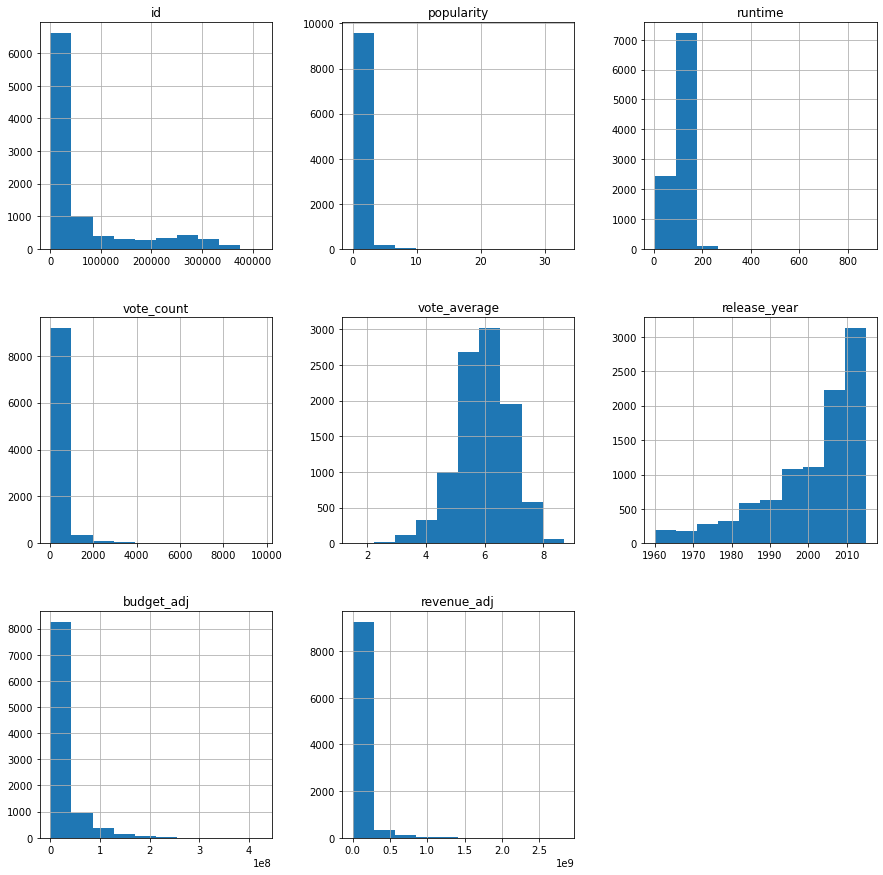

```python
df_movies_tmdb.hist(bins = 10, figsize = (15,15));
```

From the histograms above, we can see that more movies are released as the years go by, most movies are rated between 5 and 7 based on vote_average.

### Question 1: Which movies receive the highest rating?(Top 10)

```python
top_10_rating = df_movies_tmdb.nlargest(10, 'vote_average')[['original_title','vote_average']]
top_10_rating
```

|  | original_title | vote_average |
| --- | --- | --- |
| 6911 | Pink Floyd: Pulse | 8.7 |
| 3690 | The Art of Flight | 8.5 |
| 8221 | A Personal Journey with Martin Scorsese Throug... | 8.5 |
| 8411 | Queen - Rock Montreal | 8.5 |
| 609 | The Jinx: The Life and Deaths of Robert Durst | 8.4 |
| 4178 | The Shawshank Redemption | 8.4 |
| 5986 | Guten Tag, RamÃ³n | 8.4 |
| 7948 | Stop Making Sense | 8.4 |
| 1322 | One Direction: Where We Are - The Concert | 8.3 |
| 1864 | Iron Maiden: Flight 666 | 8.3 |

### Question 1: Which movies are the most popular according to tmdb?(Top 10)

```python
top_10_popular = df_movies_tmdb.sort_values('popularity', ascending = False, ignore_index = True)[['original_title', 'popularity']].head(10)
top_10_popular
```

|  | original_title | popularity |
| --- | --- | --- |
| 0 | Jurassic World | 32.985763 |
| 1 | Mad Max: Fury Road | 28.419936 |
| 2 | Interstellar | 24.949134 |
| 3 | Guardians of the Galaxy | 14.311205 |
| 4 | Insurgent | 13.112507 |
| 5 | Captain America: The Winter Soldier | 12.971027 |
| 6 | Star Wars | 12.037933 |
| 7 | John Wick | 11.422751 |
| 8 | Star Wars: The Force Awakens | 11.173104 |
| 9 | The Hunger Games: Mockingjay - Part 1 | 10.739009 |

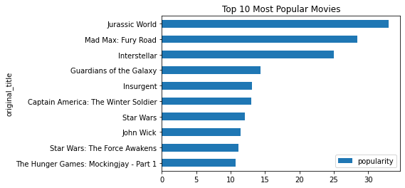

```python
#plotting
top_10_popular.plot(x = 'original_title', y = 'popularity', kind = 'barh', title = "Top 10 Most Popular Movies").invert_yaxis()
```

A breakdown of movies with the highest rating and popularity. Pink Floyd: Pulse is the best rated movie while Jurassic World is the most popular movie.

### Question 2: Which genres of movie generate the highest revenue?

```python
#From the initial exploration, it was noticed that the genre column had multiple genres combined
#First we need to split the genre column.
#What I'll be doing here is to split the genre column. This will be defined as a reusable function as we have the same issue in pother columns
#Next, I'll be computing the average revenue for each genre.

#To segment the data, I'll begin by making a copy of the initial dataset

df_genre = df_movies_tmdb.copy()

def cols_split(rep, data, old_col, new_col):
    rep = data[old_col].str.split('|').apply(pd.Series, 1).stack()
    rep.index = rep.index.droplevel(-1)
    rep.name = new_col
    pd.DataFrame(rep, columns = [new_col])
    data = data.join(rep)
    del data[old_col]
    return data
```

```python
df_genre = cols_split('g', df_genre, 'genres', 'genre')
```

```python
df_genre.shape
```

```
(24650, 13)
```

We have confirmed that the genres have been split up and the genre column contains only one genre per row.

```python
#Getting the top genres by average revenue

df_genre['revenue_adj'] = df_genre['revenue_adj'].astype(int)
df_topgenre = df_genre.groupby('genre')['revenue_adj'].mean().sort_values(ascending = False)
print(df_topgenre)
```

```
genre
Adventure          1.972770e+08
Fantasy            1.747415e+08
Animation          1.693471e+08
Family             1.622273e+08
Science Fiction    1.511873e+08
Action             1.496438e+08
War                1.282884e+08
Western            1.172323e+08
TV Movie           1.169264e+08
Thriller           1.158007e+08
Music              1.122086e+08
History            1.117757e+08
Comedy             1.110091e+08
Mystery            1.084957e+08
Crime              1.068251e+08
Romance            1.057274e+08
Drama              1.015532e+08
Horror             1.006342e+08
Foreign            9.771234e+07
Documentary        9.237391e+07
Name: revenue_adj, dtype: float64
```

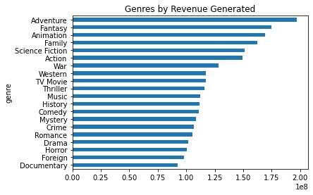

```python
df_topgenre.plot(kind = 'barh', title = 'Genres by Revenue Generated').invert_yaxis()
```

Results show that adventure is the genre that generates the highest amount of revenue while documentary generates the least revenue

### Question 3: Which of the casts is asscociated with high revenue movies?

```python
df_revenue = df_movies_tmdb.copy()
df_revenue
```

|  | id | popularity | original_title | cast | director | runtime | genres | production_companies | vote_count | vote_average | release_year | budget_adj | revenue_adj |
| --- | --- | --- | --- | --- | --- | --- | --- | --- | --- | --- | --- | --- | --- |
| 0 | 135397 | 32.985763 | Jurassic World | Chris Pratt\|Bryce Dallas Howard\|Irrfan Khan\|Vi... | Colin Trevorrow | 124.0 | Action\|Adventure\|Science Fiction\|Thriller | Universal Studios\|Amblin Entertainment\|Legenda... | 5562 | 6.5 | 2015 | 1.379999e+08 | 1.392446e+09 |
| 1 | 76341 | 28.419936 | Mad Max: Fury Road | Tom Hardy\|Charlize Theron\|Hugh Keays-Byrne\|Nic... | George Miller | 120.0 | Action\|Adventure\|Science Fiction\|Thriller | Village Roadshow Pictures\|Kennedy Miller Produ... | 6185 | 7.1 | 2015 | 1.379999e+08 | 3.481613e+08 |
| 2 | 262500 | 13.112507 | Insurgent | Shailene Woodley\|Theo James\|Kate Winslet\|Ansel... | Robert Schwentke | 119.0 | Adventure\|Science Fiction\|Thriller | Summit Entertainment\|Mandeville Films\|Red Wago... | 2480 | 6.3 | 2015 | 1.012000e+08 | 2.716190e+08 |
| 3 | 140607 | 11.173104 | Star Wars: The Force Awakens | Harrison Ford\|Mark Hamill\|Carrie Fisher\|Adam D... | J.J. Abrams | 136.0 | Action\|Adventure\|Science Fiction\|Fantasy | Lucasfilm\|Truenorth Productions\|Bad Robot | 5292 | 7.5 | 2015 | 1.839999e+08 | 1.902723e+09 |
| 4 | 168259 | 9.335014 | Furious 7 | Vin Diesel\|Paul Walker\|Jason Statham\|Michelle ... | James Wan | 137.0 | Action\|Crime\|Thriller | Universal Pictures\|Original Film\|Media Rights ... | 2947 | 7.3 | 2015 | 1.747999e+08 | 1.385749e+09 |
| ... | ... | ... | ... | ... | ... | ... | ... | ... | ... | ... | ... | ... | ... |
| 10861 | 21 | 0.080598 | The Endless Summer | Michael Hynson\|Robert August\|Lord 'Tally Ho' B... | Bruce Brown | 95.0 | Documentary | Bruce Brown Films | 11 | 7.4 | 1966 | 3.778790e+07 | 1.173732e+08 |
| 10862 | 20379 | 0.065543 | Grand Prix | James Garner\|Eva Marie Saint\|Yves Montand\|Tosh... | John Frankenheimer | 176.0 | Action\|Adventure\|Drama | Cherokee Productions\|Joel Productions\|Douglas ... | 20 | 5.7 | 1966 | 3.778790e+07 | 1.173732e+08 |
| 10863 | 39768 | 0.065141 | Beregis Avtomobilya | Innokentiy Smoktunovskiy\|Oleg Efremov\|Georgi Z... | Eldar Ryazanov | 94.0 | Mystery\|Comedy | Mosfilm | 11 | 6.5 | 1966 | 3.778790e+07 | 1.173732e+08 |
| 10864 | 21449 | 0.064317 | What's Up, Tiger Lily? | Tatsuya Mihashi\|Akiko Wakabayashi\|Mie Hama\|Joh... | Woody Allen | 80.0 | Action\|Comedy | Benedict Pictures Corp. | 22 | 5.4 | 1966 | 3.778790e+07 | 1.173732e+08 |
| 10865 | 22293 | 0.035919 | Manos: The Hands of Fate | Harold P. Warren\|Tom Neyman\|John Reynolds\|Dian... | Harold P. Warren | 74.0 | Horror | Norm-Iris | 15 | 1.5 | 1966 | 1.276423e+05 | 1.173732e+08 |

9772 rows × 13 columns

```python
df_revenues = df_revenue.nlargest(50, 'revenue_adj')
df_revenues.shape
```

```
(50, 13)
```

```python
df_cast = df_revenues.copy()
```

```python
df_cast = cols_split('c', df_cast, 'cast', 'movie_cast')
```

```python
df_cast.shape
```

```
(250, 13)
```

```python
df_topcast = df_cast.groupby('movie_cast')['movie_cast'].count().reset_index(name = 'count')
df_topcast.sort_values('count', ascending = False, ignore_index = True, inplace = True)
df_topcast['count'] = df_topcast['count'].astype(int)
print(df_topcast.query('count > 2'))
```

```
           movie_cast  count
0    Daniel Radcliffe      5
1       Orlando Bloom      5
2        Rupert Grint      5
3         Emma Watson      5
4       Harrison Ford      4
5       Carrie Fisher      4
6         Mark Hamill      4
7         Johnny Depp      4
8        Ian McKellen      4
9     Viggo Mortensen      3
10        Elijah Wood      3
11          Liv Tyler      3
12      Ralph Fiennes      3
13  Robert Downey Jr.      3
```

```python
df_top = df_cast['movie_cast'].value_counts().reset_index(name = 'count')
print (df_top.query('count > 2'))
```

```
                index  count
0         Emma Watson      5
1        Rupert Grint      5
2    Daniel Radcliffe      5
3       Orlando Bloom      5
4        Ian McKellen      4
5         Johnny Depp      4
6       Harrison Ford      4
7         Mark Hamill      4
8       Carrie Fisher      4
9           Liv Tyler      3
10  Robert Downey Jr.      3
11      Ralph Fiennes      3
12        Elijah Wood      3
13    Viggo Mortensen      3
```

Here, the goal was to confirm casts who have acted in over two high revenue movies. This can point to casts who are likely to make a movie succesful.

### Qustion 4: How many movies has a cast been associated with?

```python
df_movie_cast = df_movies_tmdb

df_movie_cast = cols_split('mc', df_movie_cast, 'cast', 'movie_cast')
```

```python
df_top_moviecast = df_movie_cast.groupby('movie_cast')['movie_cast'].count().reset_index(name = 'count')
df_top_moviecast = df_top_moviecast.nlargest(20, 'count')[['movie_cast', 'count']]
df_top_moviecast
```

|  | movie_cast | count |
| --- | --- | --- |
| 13805 | Robert De Niro | 72 |
| 14464 | Samuel L. Jackson | 70 |
| 2251 | Bruce Willis | 62 |
| 12272 | Nicolas Cage | 61 |
| 11344 | Michael Caine | 52 |
| 13968 | Robin Williams | 51 |
| 11895 | Morgan Freeman | 49 |
| 8065 | John Cusack | 48 |
| 8106 | John Goodman | 48 |
| 350 | Alec Baldwin | 47 |
| 9942 | Liam Neeson | 47 |
| 15516 | Susan Sarandon | 47 |
| 8669 | Julianne Moore | 46 |
| 16096 | Tom Hanks | 46 |
| 4163 | Dennis Quaid | 45 |
| 5635 | Gene Hackman | 45 |
| 11292 | Meryl Streep | 44 |
| 15576 | Sylvester Stallone | 44 |
| 16785 | Willem Dafoe | 44 |
| 3225 | Clint Eastwood | 43 |

The results show the top 20 cast that have acted in the highest number of movies. Robert De Niro is the highest casted actor with 72 movies.

### Question 5: Does runtime affect movie rating/popularity?

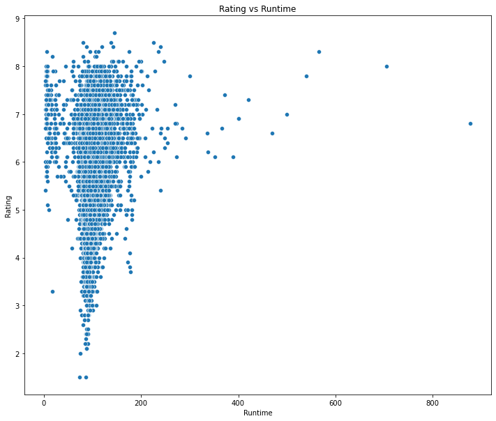

```python
plt.figure(figsize = (12,10))
sns.scatterplot(data = df_movies_tmdb,x = 'runtime',y = 'vote_average')
plt.title('Rating vs Runtime') #title
plt.xlabel('Runtime') #x label
plt.ylabel('Rating') #y label
plt.show()
```

Based on the plot above, movies with more runtime generally get good ratings. However, runtime may not be a determinant for good rating as movies with shorter runtimes also have good rating.

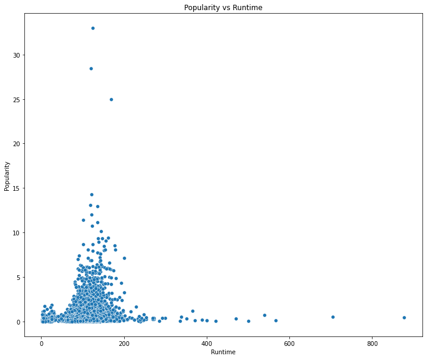

```python
plt.figure(figsize = (12,10))
sns.scatterplot(data = df_movies_tmdb,x = 'runtime',y = 'popularity')
plt.title('Popularity vs Runtime') #title
plt.xlabel('Runtime') #x label
plt.ylabel('Popularity') #y label
plt.show()
```

We see a concentration of movies with runtime between 0 and 200 fall within a popularity band of 0 and 5. Based on this plot, we see movies with longer runtimes have popularies between 0 and 1. However, because these are very few of the movies, runtime may not be a good determinant for popularity.

### Question 6: Are rating and revenue related?

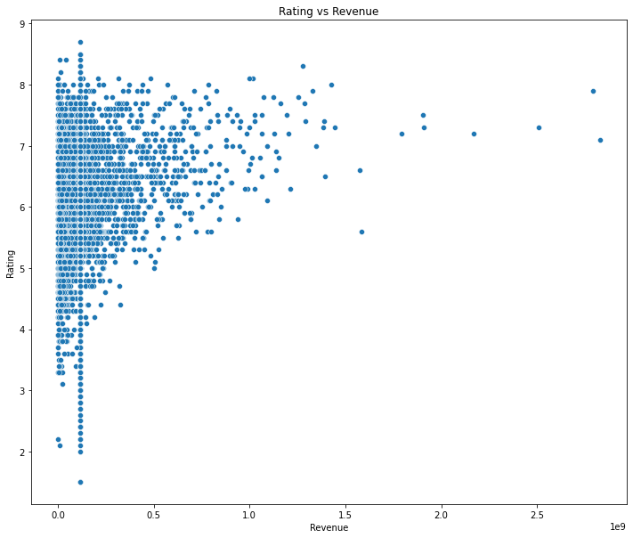

```python
plt.figure(figsize = (12,10))
sns.scatterplot(data = df_movies_tmdb,x = 'revenue_adj',y = 'vote_average')
plt.title('Rating vs Revenue') #title
plt.xlabel('Revenue') #x label
plt.ylabel('Rating') #y label
plt.show()
```

From the plot, we see that high grossing movies generally have good ratings.

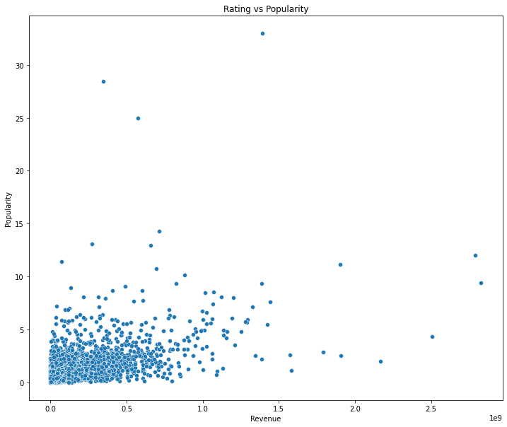

```python
plt.figure(figsize = (12,10))
sns.scatterplot(data = df_movies_tmdb,x = 'revenue_adj',y = 'popularity')
plt.title('Rating vs Popularity') #title
plt.xlabel('Revenue') #x label
plt.ylabel('Popularity') #y label
plt.show()
```

### Question 7: Which directors are associated with high revenue movies?

```python
#splittung columns with multiple directors
df_director = df_movies_tmdb.copy()

df_director = cols_split('d', df_director, 'director', 'movie_director')
```

```python
df_director.shape #to verify that there is only one director per movie
df_director.head()
```

|  | id | popularity | original_title | cast | runtime | genres | production_companies | vote_count | vote_average | release_year | budget_adj | revenue_adj | movie_director |
| --- | --- | --- | --- | --- | --- | --- | --- | --- | --- | --- | --- | --- | --- |
| 0 | 135397 | 32.985763 | Jurassic World | Chris Pratt\|Bryce Dallas Howard\|Irrfan Khan\|Vi... | 124.0 | Action\|Adventure\|Science Fiction\|Thriller | Universal Studios\|Amblin Entertainment\|Legenda... | 5562 | 6.5 | 2015 | 1.379999e+08 | 1.392446e+09 | Colin Trevorrow |
| 1 | 76341 | 28.419936 | Mad Max: Fury Road | Tom Hardy\|Charlize Theron\|Hugh Keays-Byrne\|Nic... | 120.0 | Action\|Adventure\|Science Fiction\|Thriller | Village Roadshow Pictures\|Kennedy Miller Produ... | 6185 | 7.1 | 2015 | 1.379999e+08 | 3.481613e+08 | George Miller |
| 2 | 262500 | 13.112507 | Insurgent | Shailene Woodley\|Theo James\|Kate Winslet\|Ansel... | 119.0 | Adventure\|Science Fiction\|Thriller | Summit Entertainment\|Mandeville Films\|Red Wago... | 2480 | 6.3 | 2015 | 1.012000e+08 | 2.716190e+08 | Robert Schwentke |
| 3 | 140607 | 11.173104 | Star Wars: The Force Awakens | Harrison Ford\|Mark Hamill\|Carrie Fisher\|Adam D... | 136.0 | Action\|Adventure\|Science Fiction\|Fantasy | Lucasfilm\|Truenorth Productions\|Bad Robot | 5292 | 7.5 | 2015 | 1.839999e+08 | 1.902723e+09 | J.J. Abrams |
| 4 | 168259 | 9.335014 | Furious 7 | Vin Diesel\|Paul Walker\|Jason Statham\|Michelle ... | 137.0 | Action\|Crime\|Thriller | Universal Pictures\|Original Film\|Media Rights ... | 2947 | 7.3 | 2015 | 1.747999e+08 | 1.385749e+09 | James Wan |

```python
df_director = df_director.groupby('movie_director')['revenue_adj'].mean().reset_index(name = 'Average_Revenue')
df_director.sort_values('Average_Revenue', ascending = False, ignore_index = True, inplace = True)
df_director['Average_Revenue'] = df_director['Average_Revenue'].astype(int)
print(df_director.head(20))
```

```
      movie_director  Average_Revenue
0     Clyde Geronimi       1574814739
1     Hamilton Luske       1574814739
2       George Lucas       1052319860
3        David Yates       1044363814
4        Joss Whedon        926407996
5        Lee Unkrich        854017658
6      Pierre Coffin        838790501
7      James Cameron        756196731
8       Bob Peterson        743337082
9      Conrad Vernon        719684876
10  Robert Stromberg        698565011
11   Colin Trevorrow        698126135
12      Chris Miller        689121487
13       J.J. Abrams        682935397
14      Jennifer Lee        655042359
15      Jennifer Yuh        645320794
16    John Stevenson        639822446
17   David Silverman        623701641
18       Pete Docter        584805854
19       Shane Black        577658744
```

Clyde Geronimi and Hamilton Luske have directed movies with the highest revenue.

### Question 8: Is rating/popularity affected by vote count?

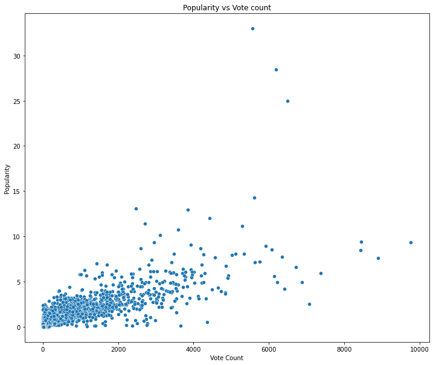

```python
plt.figure(figsize = (12,10))
sns.scatterplot(data = df_movies_tmdb,x = 'vote_count',y = 'popularity')
plt.title('Popularity vs Vote count') #title
plt.xlabel('Vote Count') #x label
plt.ylabel('Popularity') #y label
plt.show()
```

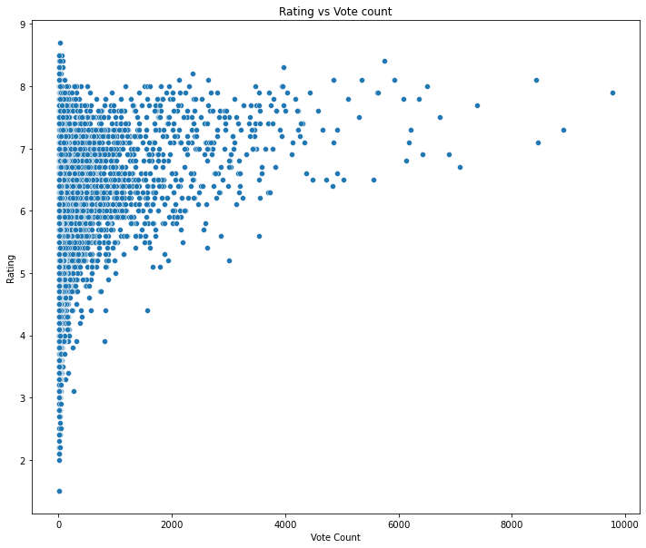

```python
plt.figure(figsize = (12,10))
sns.scatterplot(data = df_movies_tmdb,x = 'vote_count',y = 'vote_average')
plt.title('Rating vs Vote count') #title
plt.xlabel('Vote Count') #x label
plt.ylabel('Rating') #y label
plt.show()
```

### Question 9: How many movies were profitable?

```python
df_movies_profitable = len(df_movies_tmdb.query('revenue_adj > budget_adj'))
df_movies_profitable
```

```
8007
```

8007 movies were profitable of the 9772 movies

### Question 10: Profitability over the years

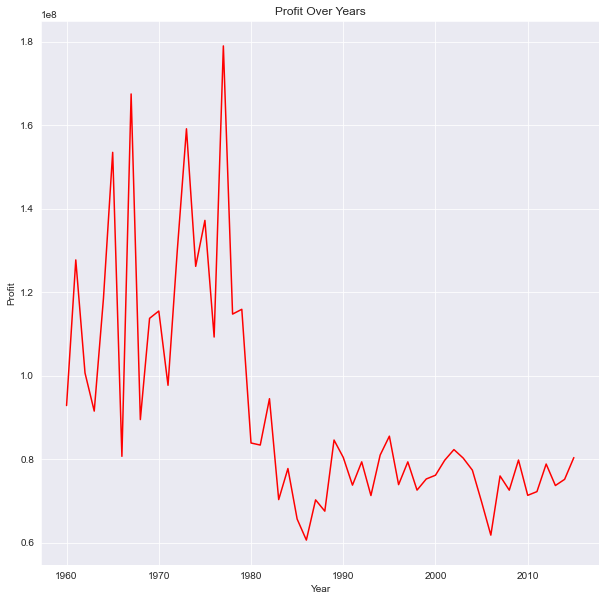

```python
df_movies_tmdb['profit'] = df_movies_tmdb['revenue_adj'] - df_movies_tmdb['budget_adj']
df_movies_tmdb['profit'] = df_movies_tmdb['profit'].astype(int)
profit_by_year = df_movies_tmdb.groupby('release_year')['profit'].mean()
#df_movies_tmdb.plot(y = 'profit', x = 'release_year', kind = 'line')

sns.set_style('darkgrid')
x = profit_by_year.index
y = profit_by_year
plt.figure(figsize=(10,10))
plt.plot(x, y, color='red')
plt.title('Profit Over Years')
plt.xlabel('Year')
plt.ylabel('Profit')
plt.show();
```

Movie profitability was higher in the earlier years but has declined in later years

### Question 11: Popularity over the years

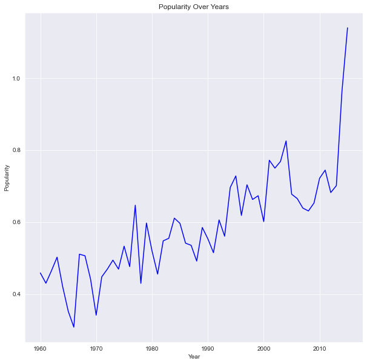

```python
popularity_by_year = df_movies_tmdb.groupby('release_year')['popularity'].mean()
#df_movies_tmdb.plot(y = 'profit', x = 'release_year', kind = 'line')

sns.set_style('darkgrid')
x = popularity_by_year.index
y = popularity_by_year
plt.figure(figsize=(10,10))
plt.plot(x, y, color='blue')
plt.title('Popularity Over Years')
plt.xlabel('Year')
plt.ylabel('Popularity')
plt.show();
```

Popularity has seen a rise over the years.

#### Conclusions

Limitations

1. 1094 out 0f 10866 rows had to be dropped for the analysis.
2. Revenue and budget are assumed to be in dollars.
3. I had to work with the revenue_adj and budget_adj columns